# Week 5 - Dimensionality reduction techniques

This first chunk is just for downloading data and libraries.

```r
date()
```

```
## [1] "Tue Nov 24 21:07:59 2020"
```

```r
url="http://s3.amazonaws.com/assets.datacamp.com/production/course_2218/datasets/human2.txt"

human=read.csv(url)

library(corrplot)
library(tidyverse)
library(ggplot2)
```

## Task 1

The data combines several indicators from most countries in the world

- “Country” = Country name

Health and knowledge

- “GNI” = Gross National Income per capita
- “Life.Exp” = Life expectancy at birth
- “Edu.Exp” = Expected years of schooling
- “Mat.Mor” = Maternal mortality ratio
- “Ado.Birth” = Adolescent birth rate

Empowerment

- “Parli.F” = Percetange of female representatives in parliament
- “Edu2.F” = Proportion of females with at least secondary education
- “Edu2.M” = Proportion of males with at least secondary education
- “Labo.F” = Proportion of females in the labour force
- “Labo.M” " Proportion of males in the labour force
- “Edu2.FM” = Edu2.F / Edu2.M
- “Labo.FM” = Labo2.F / Labo2.M

Summary of each individual variable:

```r
print(summary(human))
```

```
##     Edu2.FM          Labo.FM          Edu.Exp         Life.Exp
##  Min.   :0.1717   Min.   :0.1857   Min.   : 5.40   Min.   :49.00
##  1st Qu.:0.7264   1st Qu.:0.5984   1st Qu.:11.25   1st Qu.:66.30
##  Median :0.9375   Median :0.7535   Median :13.50   Median :74.20
##  Mean   :0.8529   Mean   :0.7074   Mean   :13.18   Mean   :71.65
##  3rd Qu.:0.9968   3rd Qu.:0.8535   3rd Qu.:15.20   3rd Qu.:77.25
##  Max.   :1.4967   Max.   :1.0380   Max.   :20.20   Max.   :83.50
##       GNI            Mat.Mor         Ado.Birth         Parli.F
##  Min.   :   581   Min.   :   1.0   Min.   :  0.60   Min.   : 0.00
##  1st Qu.:  4198   1st Qu.:  11.5   1st Qu.: 12.65   1st Qu.:12.40
##  Median : 12040   Median :  49.0   Median : 33.60   Median :19.30
##  Mean   : 17628   Mean   : 149.1   Mean   : 47.16   Mean   :20.91
##  3rd Qu.: 24512   3rd Qu.: 190.0   3rd Qu.: 71.95   3rd Qu.:27.95
##  Max.   :123124   Max.   :1100.0   Max.   :204.80   Max.   :57.50
```

Histograms of different variables in the data set.

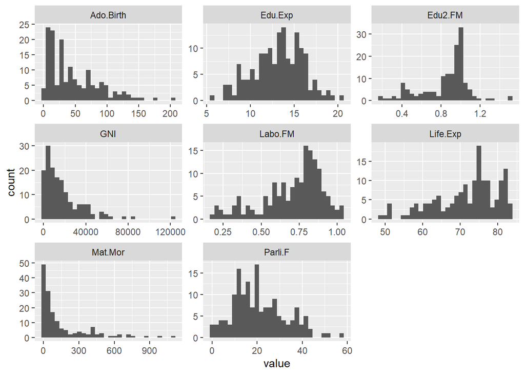

```r
human %>%
  keep(is.numeric) %>%
  gather() %>%
  ggplot(aes(value)) +
    facet_wrap(~ key, scales = "free") +
    geom_histogram()
```

Corrplot is nice way to inspect linear correlation coefficients between variables in a dataset.

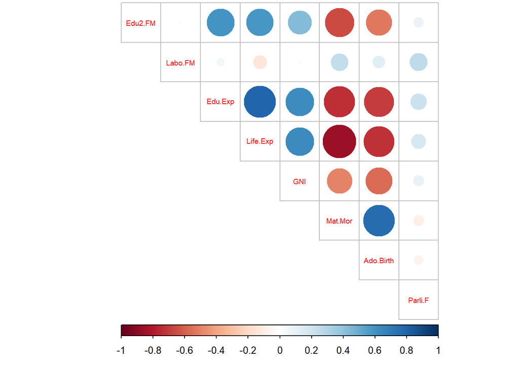

```r
cor_matrix<-cor(human) %>% round(digits=2)

corrplot(cor_matrix, method="circle", type = "upper", cl.pos = "b", tl.pos = "d", tl.cex = 0.6)
```

There are several parameters, that seems to correlate rather nicely between each other. For example it is rather obvious, that high life expectancy correlates negatively with maternal mortality rate. One thing was not so obvious, but still interesting. Proportion of females in the labour force does not correlate with anything.

## Task 2

PCA model and the biplot for non-standardized data.

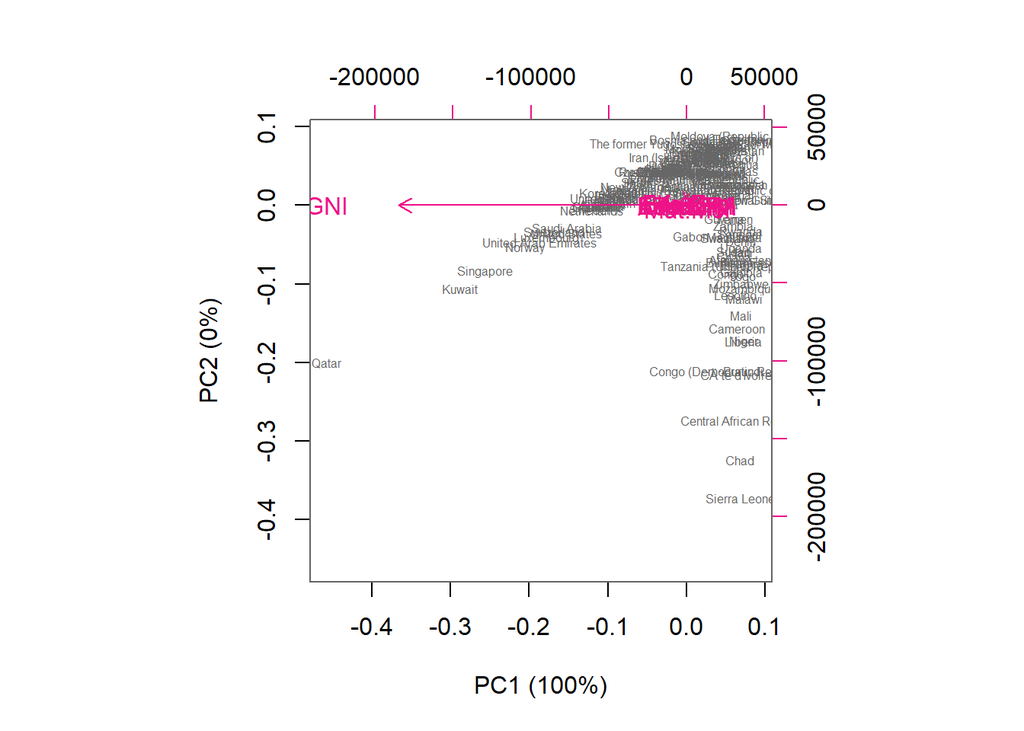

```r
## PCA model and biplot
pca_human <- prcomp(human)

s <- summary(pca_human)

# rounded percetanges of variance captured by each PC
pca_pr <- round(1*s$importance[2, ]*100, digits = 1)

# create object pc_lab to be used as axis labels
pc_lab=paste0(names(pca_pr), " (", pca_pr, "%)")

# draw a biplot
biplot(pca_human, cex = c(0.5, 1), col = c("grey40", "deeppink2"), xlab = pc_lab[1], ylab = pc_lab[2])
```

It can be clearly seen, that GNI is only explaining variable for non-standardized data.

## Task 3

Same model, but for scaled data.

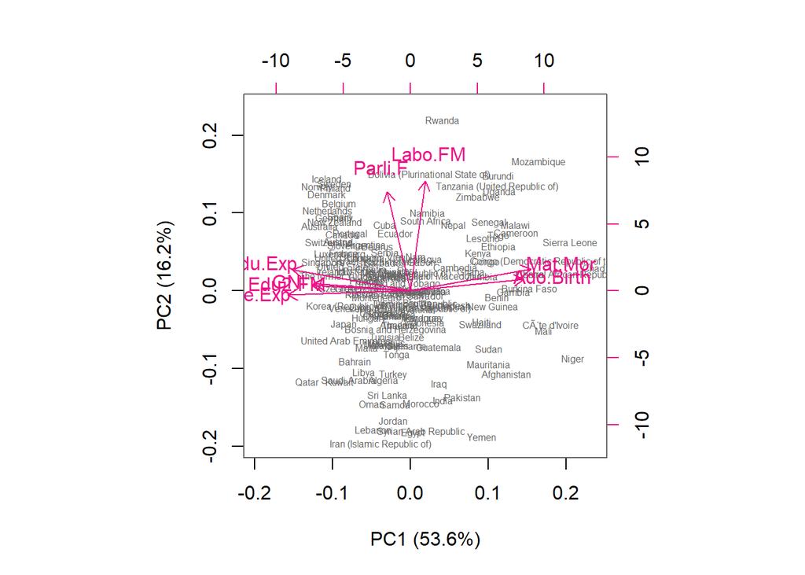

```r
human_std <- scale(human)

## PCA model and biplot
pca_human <- prcomp(human_std)

s <- summary(pca_human)

# rounded percetanges of variance captured by each PC
pca_pr <- round(1*s$importance[2, ]*100, digits = 1)

# create object pc_lab to be used as axis labels
pc_lab=paste0(names(pca_pr), " (", pca_pr, "%)")

# draw a biplot
biplot(pca_human, cex = c(0.5, 1), col = c("grey40", "deeppink2"), xlab = pc_lab[1], ylab = pc_lab[2])
```

From the data, three different groups of variable can be detected. The first group: In general, Proportion of females in the labour force (“Labo.F”) and Percetange of female representatives in parliament (“Parli.F”) seems to correlate positively. The explanation is more or less obvious. If females participate labour force, the they also participate politics.

Second group consists two variables: Maternal mortality ratio (“Mat.Mor”) and Adolescent birth rate (“Ado.Birth”). This is also rather obvious positive correlation. Maternal mortality ratio is often correlated with income level.

The third group consists last four parameters: “GNI” = Gross National Income per capita, “Life.Exp” = Life expectancy at birth, “Edu.Exp” = Expected years of schooling and Edu2.FM = Proportion of females with at least secondary education / Proportion of males with at least secondary education. These third group parameters correlate negatively with the second group.

## Task 4

First parameter is a linear combination of six parameters: GNI, Life.Exp, Edu.Exp, Edu2.FM, Mat.Mor and Ado.Birth. This parameter could be called for example “Economical index”.

Second PC parameter is a linear combination of Labo.FM and Parli.F. This parameter can be called for example “Equality index”

## Task 5

Let’s first download the data and look the structure

```r
library(FactoMineR)
data(tea)

print(str(tea))
```

```
## 'data.frame':    300 obs. of  36 variables:
##  $ breakfast       : Factor w/ 2 levels "breakfast","Not.breakfast": 1 1 2 2 1 2 1 2 1 1 ...
##  $ tea.time        : Factor w/ 2 levels "Not.tea time",..: 1 1 2 1 1 1 2 2 2 1 ...
##  $ evening         : Factor w/ 2 levels "evening","Not.evening": 2 2 1 2 1 2 2 1 2 1 ...
##  $ lunch           : Factor w/ 2 levels "lunch","Not.lunch": 2 2 2 2 2 2 2 2 2 2 ...
##  $ dinner          : Factor w/ 2 levels "dinner","Not.dinner": 2 2 1 1 2 1 2 2 2 2 ...
##  $ always          : Factor w/ 2 levels "always","Not.always": 2 2 2 2 1 2 2 2 2 2 ...
##  $ home            : Factor w/ 2 levels "home","Not.home": 1 1 1 1 1 1 1 1 1 1 ...
##  $ work            : Factor w/ 2 levels "Not.work","work": 1 1 2 1 1 1 1 1 1 1 ...
##  $ tearoom         : Factor w/ 2 levels "Not.tearoom",..: 1 1 1 1 1 1 1 1 1 2 ...
##  $ friends         : Factor w/ 2 levels "friends","Not.friends": 2 2 1 2 2 2 1 2 2 2 ...
##  $ resto           : Factor w/ 2 levels "Not.resto","resto": 1 1 2 1 1 1 1 1 1 1 ...
##  $ pub             : Factor w/ 2 levels "Not.pub","pub": 1 1 1 1 1 1 1 1 1 1 ...
##  $ Tea             : Factor w/ 3 levels "black","Earl Grey",..: 1 1 2 2 2 2 2 1 2 1 ...
##  $ How             : Factor w/ 4 levels "alone","lemon",..: 1 3 1 1 1 1 1 3 3 1 ...
```

[output cut: 23 more lines]

The dataset has 300 rows and 36 variables. For shake of simplicity, let’s narrow down the data set by removing most of the variables

```r
keep_columns <- c("Tea", "How", "how", "sugar", "where", "lunch")
tea_time <- subset(tea, select=keep_columns)

print(summary(tea_time))
```

```
##         Tea         How                      how           sugar
##  black    : 74   alone:195   tea bag           :170   No.sugar:155
##  Earl Grey:193   lemon: 33   tea bag+unpackaged: 94   sugar   :145
##  green    : 33   milk : 63   unpackaged        : 36
##                  other:  9
##                   where           lunch
##  chain store         :192   lunch    : 44
##  chain store+tea shop: 78   Not.lunch:256
##  tea shop            : 30
##
```

Let’s visualize the data set.

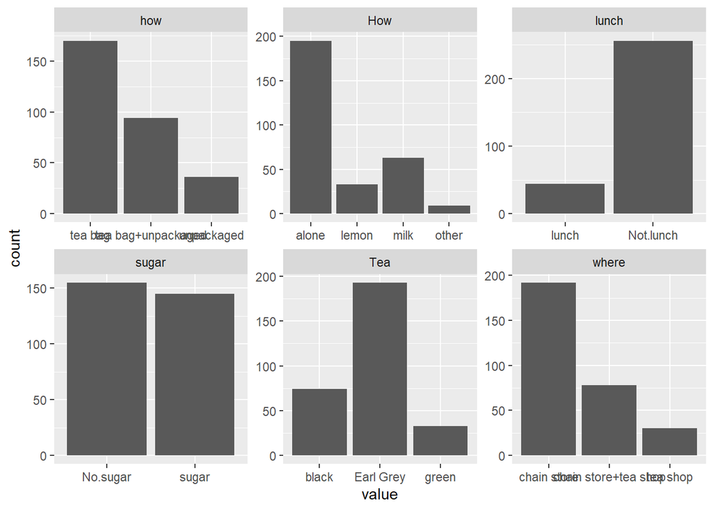

```r
# visualize the dataset
gather(tea_time) %>% ggplot(aes(value)) + facet_wrap("key", scales = "free") + geom_bar()
```

```r
theme(axis.text.x = element_text(angle = 45, hjust = 1, size = 8))
```

[output not shown]

Data shows that: People prefer Earl Grey tea and has no lear opinion about sugar.

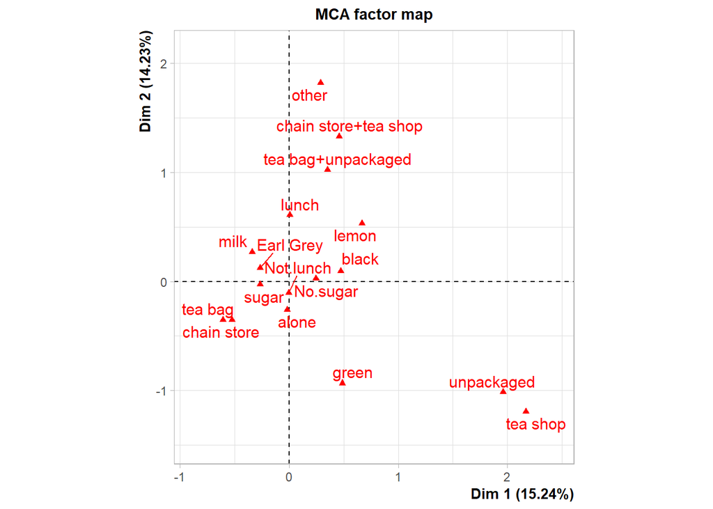

```r
# multiple correspondence analysis
mca <- MCA(tea_time, graph = FALSE)

# summary of the model


# visualize MCA
plot(mca, invisible=c("ind"))
```

Data clearly shows, that we have a strong hipster cluster. The people, that drinks unpacked tea buys that from tea shops.